# Triad Polysemy Induction Tasks

5 July 2016

#### Introduction

1. A key debate in developmental psych concerns the role of labels in how children learn and use categories.
2. Give v brief rundown of broader evidence eg waxman
3. But Perhaps the most well articulated debate is gelman sloutsky. Two line summary
4. The assumption behind these debates is that children use labels as these are robust category markers, eg for statistical or conceptual reasons.
5. But that’s not quite right: Labels are not robust category markers, in that almost all labels are used to refer to multiple different categories. We call this phenomenon lexical flexibility
6. Here we investigate what the presence of lex flex means for the role of labels in how children reason about concepts and categories.

#### Gelman Sloutsky debate

1. Broader overview and history of gelman sloutsky debate. Perhaps end with final experiment in Sloutsky Fisher JECP, where they show that even phonological similarity between words can affect children’s induction, and that the size of this effect is not mediated by similarity of the two concepts under comparison.
2. What do these theories say about lex flex? Gelman - labels are category markers. To the degree that a labels meaning can be discerned, there shouldn’t be a problem, as reasoning is done based on kinds, not labels. Sloutsky - labels contribute to similarity. Overlapping labels should contribute to similarity judgments and thereby cause children to “hallucinate” that distinct kinds are the same.

#### Calculations for getting a few predictions from the Sloutsky & Fisher model.

Sloutsky & Fisher’s lovely model presumes that induction judgments are based on the relative similarity of a Target picture to a picture X, and to a picture Y. As they show, this can be reduced to p(Y) = 1/(1 + (W * S_X) / W * S_Y), where W is the weight given by a shared/unshared word, S_X is similarity of X to target, and S_Y is similarity of Y to target.

Assume that if Y and target share a label then W = 1, and that if X and Target do not share a label then W = 0.1 (following S&F2004). When Y shares a label and similarity ratio = 1 then p(Y) = 1/(1+((0.1*0.5)/0.5)) = 0.91, but when Y does not share a label then p(Y) = 1/(1+((1*0.5)/0.5)) = 0.5

If similarity ratio = 10 then shared label p(Y) = 1/(1+((0.1*0.5)/0.05)) = 0.5 while non-shared label p(Y) = 1/(1+((1*0.5)/0.05)) = 0.09.

If similarity ratio = 100 then shared label p(Y) = 1/(1+((0.1 * 0.5)/0.005)) = 0.09 while non-shared label p(Y) = 1/(1+((1*0.5)/0.005)) = 0.01.

Adding a label still provides a 10%age point increase in p(Y) if the Y picture is 78.125 times less similar to the target than the X picture. (code: 1/(1+((0.1*0.5)/0.0064)) - 1/(1+((1*0.5)/0.0064)) which produces a 10 percentage point increase in probability of choosing Y.)

Finally, in the discussion section of the paper we note that we can estimate the relative similarity of pictures in the Different Sense condition by looking at the proportion of trials on which participants choose the Dissimilar Test picture in the No Label condition of Experiment 1.

- p(y) = 0.27 = 1/ (1+((1*x)/1*y))
- 0.27 * (1+((1*x)/1*y)) = 1
- 0.27 * (1+(ratio)) = 1
- 1+(ratio) = 1/0.27
- ratio = 1/0.27 - 1 = 2.7037037

We can use this value to calculate what the predicted effect of shared label should be in this case.

If the Y picture is 2.7 times less similar to the target than the X picture. (code: 1/(1+((0.1*0.5)/0.1851)) - 1/(1+((1*0.5)/0.1851)) then adding a shared label produces a 52 percentage point increase in probability of choosing Y, from 0.27 to 0.79.

#### Experiment 1

This vs chicken experiment. We compare label (this chicken, this chicken) with no label (this one, this one).

##### Adults

```
## [1] "Unambig 12"
```

```
## [1] "Ambig 12"
```

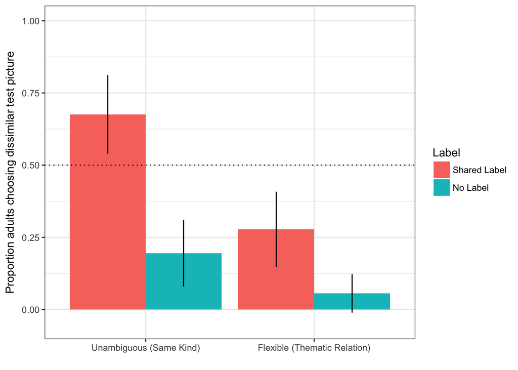

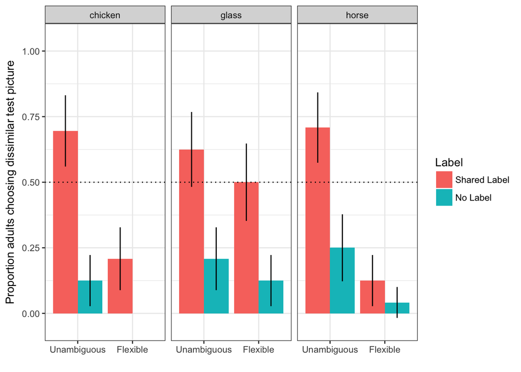

Label * Meaning mixed effects model, followed by t-tests against chance for each condition.

```
## [1] "adult female =  14"
```

```
##   age.FUN1 age.FUN2 age.FUN3
## 1    22.25       18       31
```

|  | Estimate | Std. Error | z value | Pr(>\|z\|) |
| --- | --- | --- | --- | --- |
| (Intercept) | -1.21 | 0.29 | -4.22 | 0.00 |
| Label.L | -1.52 | 0.40 | -3.83 | 0.00 |
| Meaning.L | -1.31 | 0.33 | -4.02 | 0.00 |
| Label.L:Meaning.L | 0.39 | 0.52 | 0.75 | 0.45 |

| Meaning | Label | Choice.mean | Choice.sd |
| --- | --- | --- | --- |
| Unambiguous (Same Kind) | Shared Label | 0.6777778 | 0.2955335 |
| Unambiguous (Same Kind) | No Label | 0.1944444 | 0.1857735 |
| Flexible (Thematic Relation) | Shared Label | 0.2777778 | 0.2872135 |
| Flexible (Thematic Relation) | No Label | 0.0555556 | 0.1085565 |

```
##
##  One Sample t-test
##
## data:  subset(Adult.Sum, Meaning == "Unambiguous (Same Kind)" & Label ==     "Shared Label")$Choice
## t = 2.0838, df = 11, p-value = 0.06129
## alternative hypothesis: true mean is not equal to 0.5
## 95 percent confidence interval:
##  0.4900047 0.8655508
## sample estimates:
## mean of x
## 0.6777778
```

```
##
##  One Sample t-test
##
## data:  subset(Adult.Sum, Meaning == "Unambiguous (Same Kind)" & Label ==     "No Label")$Choice
## t = -5.6977, df = 11, p-value = 0.0001387
## alternative hypothesis: true mean is not equal to 0.5
## 95 percent confidence interval:
##  0.07640961 0.31247928
## sample estimates:
## mean of x
## 0.1944444
```

```
##
##  One Sample t-test
##
## data:  subset(Adult.Sum, Meaning == "Flexible (Thematic Relation)" &     Label == "Shared Label")$Choice
## t = -2.6802, df = 11, p-value = 0.0214
## alternative hypothesis: true mean is not equal to 0.5
## 95 percent confidence interval:
##  0.09529104 0.46026452
## sample estimates:
## mean of x
## 0.2777778
```

```
##
##  One Sample t-test
##
## data:  subset(Adult.Sum, Meaning == "Flexible (Thematic Relation)" &     Label == "No Label")$Choice
## t = -14.182, df = 11, p-value = 2.053e-08
## alternative hypothesis: true mean is not equal to 0.5
## 95 percent confidence interval:
##  -0.01341795  0.12452906
## sample estimates:
##  mean of x
## 0.05555556
```

##### Children

```
## [1] "Unambig 3 yrs 24"
```

```
## [1] "Unambig 4 yrs 25"
```

```
## [1] "Ambig 3 yrs 24"
```

```
## [1] "Ambig 4 yrs 24"
```

```
## [1] "3 yrs girls =  22"
```

```
## [1] "4 yrs girls =  23"
```

```
##   age age.months.FUN1 age.months.FUN2 age.months.FUN3
## 1   3        43.76729        36.32877        47.90137
## 2   4        54.47649        48.26301        59.83562
```

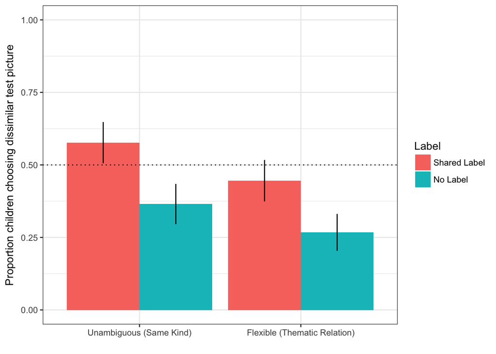

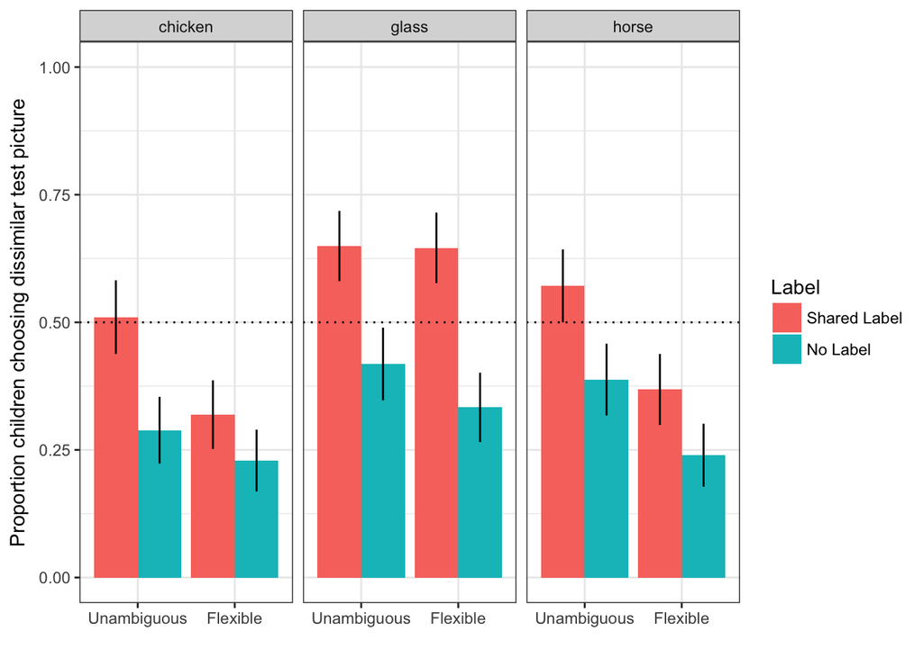

Label * Meaning mixed effects model, followed by t-tests against chance for each condition.

|  | Estimate | Std. Error | z value | Pr(>\|z\|) |
| --- | --- | --- | --- | --- |
| (Intercept) | -0.43 | 0.22 | -1.97 | 0.05 |
| Label.L | -0.69 | 0.14 | -4.94 | 0.00 |
| Meaning.L | -0.41 | 0.12 | -3.51 | 0.00 |
| Label.L:Meaning.L | 0.06 | 0.19 | 0.29 | 0.78 |

|  | Estimate | Std. Error | z value | Pr(>\|z\|) |
| --- | --- | --- | --- | --- |
| (Intercept) | -0.14 | 0.17 | -0.79 | 0.43 |
| Label.L | -0.73 | 0.21 | -3.43 | 0.00 |

|  | Estimate | Std. Error | z value | Pr(>\|z\|) |
| --- | --- | --- | --- | --- |
| (Intercept) | -0.72 | 0.29 | -2.47 | 0.01 |
| Label.L | -0.66 | 0.18 | -3.64 | 0.00 |

| Meaning | Label | Choice.mean | Choice.sd |
| --- | --- | --- | --- |
| Unambiguous (Same Kind) | Shared Label | 0.5782313 | 0.2744988 |
| Unambiguous (Same Kind) | No Label | 0.3659864 | 0.2598513 |
| Flexible (Thematic Relation) | Shared Label | 0.4454861 | 0.2507139 |
| Flexible (Thematic Relation) | No Label | 0.2673611 | 0.2221206 |

```
##
##  One Sample t-test
##
## data:  subset(Child.Sum, Meaning == "Unambiguous (Same Kind)" & Label ==     "Shared Label")$Choice
## t = 1.995, df = 48, p-value = 0.05174
## alternative hypothesis: true mean is not equal to 0.5
## 95 percent confidence interval:
##  0.4993860 0.6570766
## sample estimates:
## mean of x
## 0.5782313
```

```
##
##  One Sample t-test
##
## data:  subset(Child.Sum, Meaning == "Unambiguous (Same Kind)" & Label ==     "No Label")$Choice
## t = -3.6101, df = 48, p-value = 0.0007292
## alternative hypothesis: true mean is not equal to 0.5
## 95 percent confidence interval:
##  0.2913484 0.4406244
## sample estimates:
## mean of x
## 0.3659864
```

```
##
##  One Sample t-test
##
## data:  subset(Child.Sum, Meaning == "Flexible (Thematic Relation)" &     Label == "Shared Label")$Choice
## t = -1.5064, df = 47, p-value = 0.1386
## alternative hypothesis: true mean is not equal to 0.5
## 95 percent confidence interval:
##  0.3726864 0.5182858
## sample estimates:
## mean of x
## 0.4454861
```

```
##
##  One Sample t-test
##
## data:  subset(Child.Sum, Meaning == "Flexible (Thematic Relation)" &     Label == "No Label")$Choice
## t = -7.2563, df = 47, p-value = 3.344e-09
## alternative hypothesis: true mean is not equal to 0.5
## 95 percent confidence interval:
##  0.2028640 0.3318582
## sample estimates:
## mean of x
## 0.2673611
```

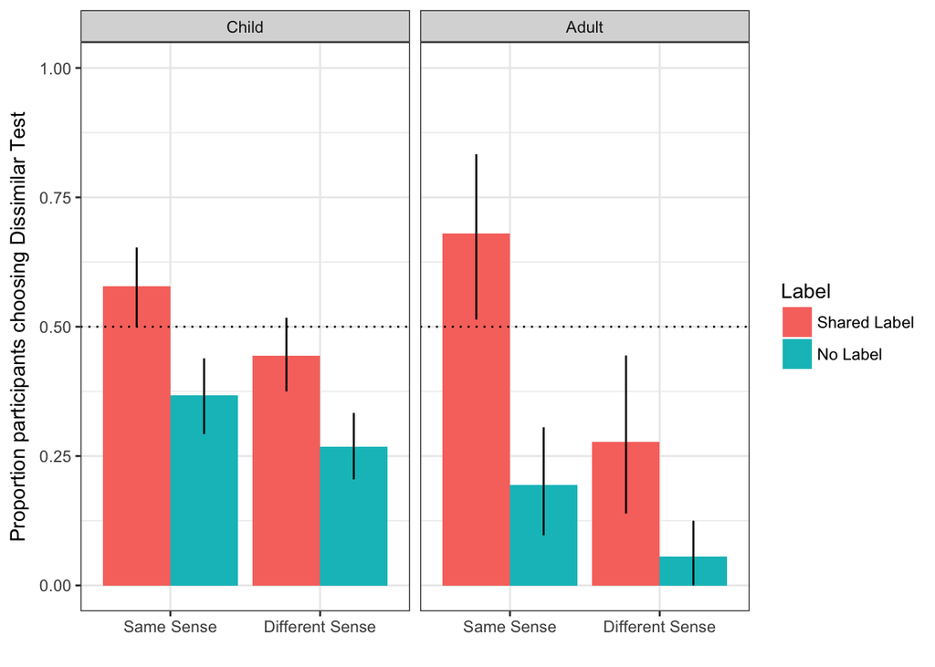

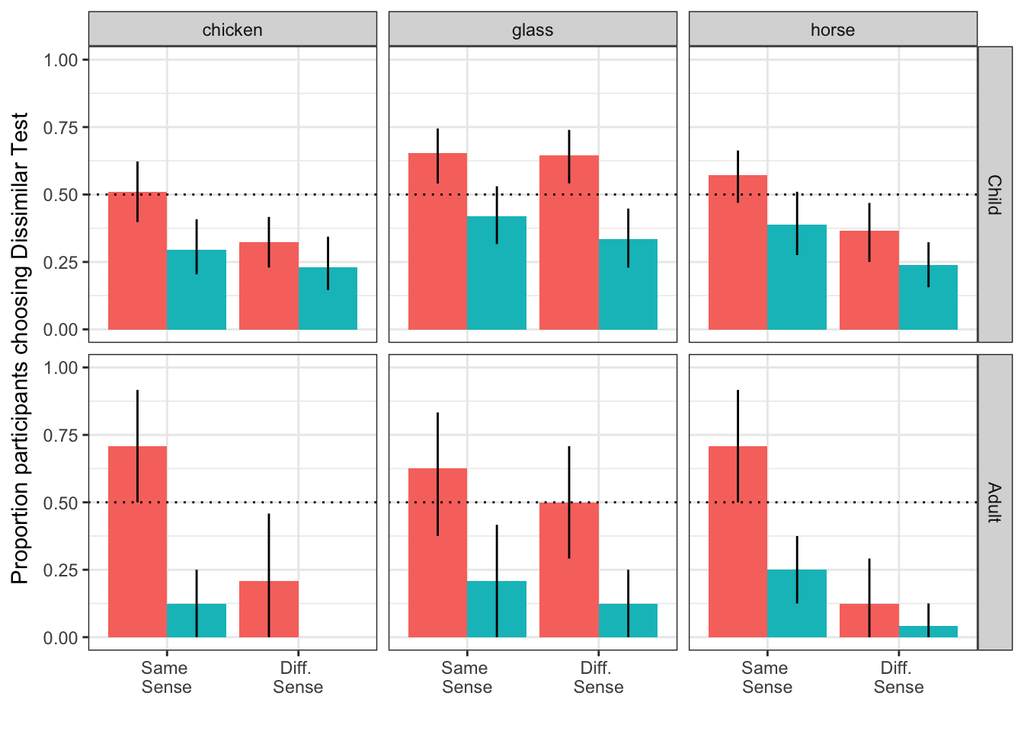

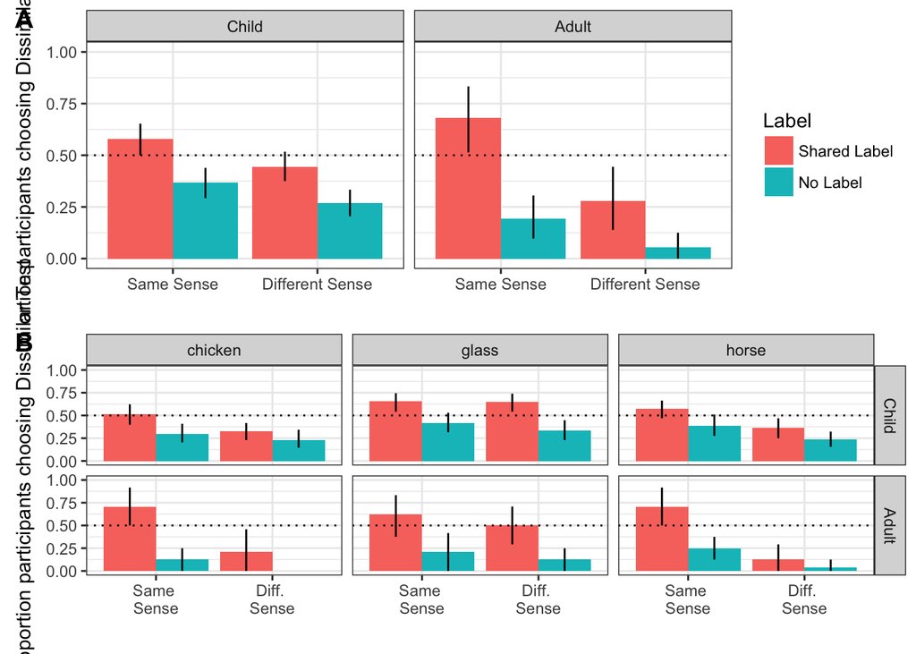

#### Discussion

Potentially evidence for Sloutsky account

But one surprising result: Adults go with label on lex flex condition. Why?

Pragmatic account? Why would they use distinct labels if they did not want us to use them?

### Experiment 2:

Always use labels, but vary if they are shared or synonyms. By sloutsky fisher JECP, should still get effect.

Here, we compare inferences from e.g., Chicken Animal to Duck, and either another Chicken Animal or Chicken Meat. We also vary whether the same label is used twice (both pictures called chicken) or whether a synonym is used (one called chicken, one called drumsticks).

### Adults

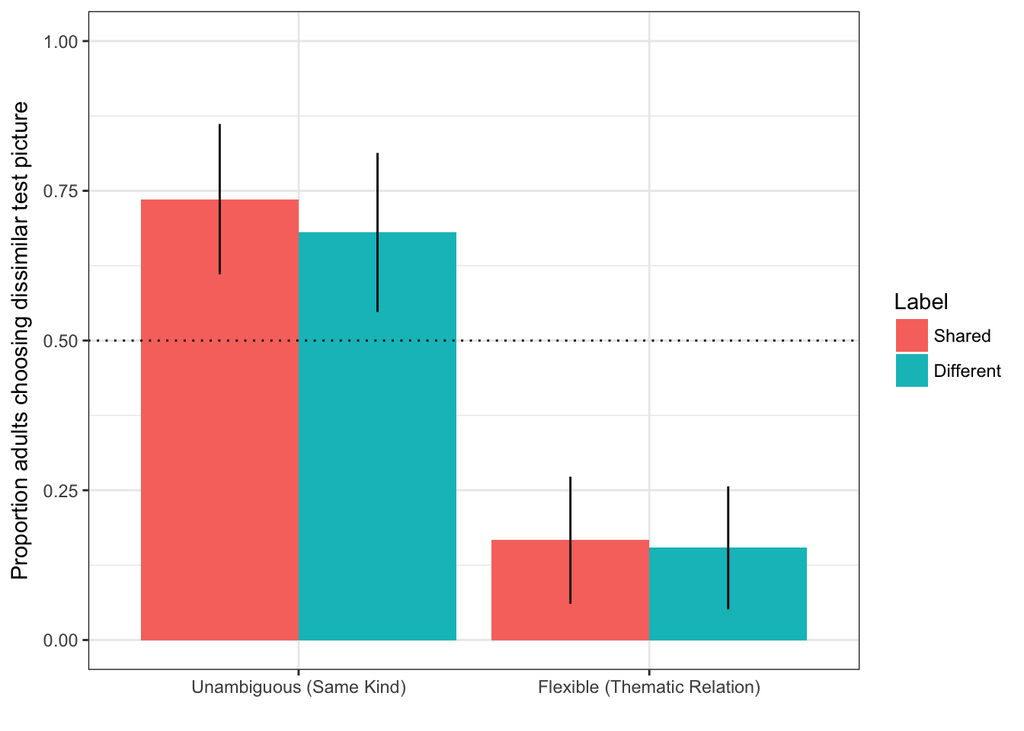

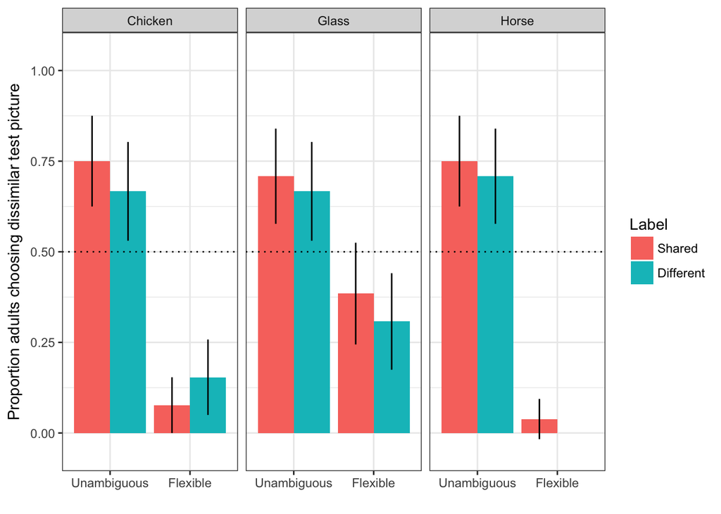

Label * Meaning mixed effects model, followed by t-tests against chance for each condition.

```
## [1] "Unambig 12"
```

```
## [1] "Polysemy 13"
```

|  | Estimate | Std. Error | z value | Pr(>\|z\|) |
| --- | --- | --- | --- | --- |
| (Intercept) | 1.36 | 0.52 | 2.60 | 0.01 |
| WordTypePolysemous | -3.29 | 0.71 | -4.64 | 0.00 |
| LabelTypeDifferent | -0.50 | 0.47 | -1.07 | 0.29 |
| WordTypePolysemous:LabelTypeDifferent | 0.57 | 0.73 | 0.79 | 0.43 |

|  | Estimate | Std. Error | z value | Pr(>\|z\|) |
| --- | --- | --- | --- | --- |
| (Intercept) | 1.49 | 0.59 | 2.51 | 0.01 |
| LabelTypeDifferent | -0.60 | 0.51 | -1.17 | 0.24 |

|  | Estimate | Std. Error | z value | Pr(>\|z\|) |
| --- | --- | --- | --- | --- |
| (Intercept) | -2.19 | 0.87 | -2.53 | 0.01 |
| LabelTypeDifferent | 0.01 | 0.58 | 0.01 | 0.99 |

| WordType | LabelType | Choice.mean | Choice.sd |
| --- | --- | --- | --- |
| Non-Polysemous | Same | 0.7361111 | 0.2883104 |
| Non-Polysemous | Different | 0.6805556 | 0.2405626 |
| Polysemous | Same | 0.1666667 | 0.1666667 |
| Polysemous | Different | 0.1538462 | 0.1437194 |

```
##
##  One Sample t-test
##
## data:  subset(Adult.Sum, WordType == "Non-Polysemous" & LabelType ==     "Same")$Choice
## t = 2.8369, df = 11, p-value = 0.01617
## alternative hypothesis: true mean is not equal to 0.5
## 95 percent confidence interval:
##  0.5529274 0.9192948
## sample estimates:
## mean of x
## 0.7361111
```

```
##
##  One Sample t-test
##
## data:  subset(Adult.Sum, WordType == "Non-Polysemous" & LabelType ==     "Different")$Choice
## t = 2.6, df = 11, p-value = 0.02469
## alternative hypothesis: true mean is not equal to 0.5
## 95 percent confidence interval:
##  0.5277094 0.8334017
## sample estimates:
## mean of x
## 0.6805556
```

```
##
##  One Sample t-test
##
## data:  subset(Adult.Sum, WordType == "Polysemous" & LabelType == "Different")$Choice
## t = -8.6841, df = 12, p-value = 1.608e-06
## alternative hypothesis: true mean is not equal to 0.5
## 95 percent confidence interval:
##  0.06699738 0.24069493
## sample estimates:
## mean of x
## 0.1538462
```

```
##
##  One Sample t-test
##
## data:  subset(Adult.Sum, WordType == "Polysemous" & LabelType == "Same")$Choice
## t = -7.2111, df = 12, p-value = 1.07e-05
## alternative hypothesis: true mean is not equal to 0.5
## 95 percent confidence interval:
##  0.06595101 0.26738233
## sample estimates:
## mean of x
## 0.1666667
```

```
## Bayes factor analysis
## --------------
## [1] Alt., r=0.707 : 0.2831734 ±0.02%
##
## Against denominator:
##   Null, mu = 0
## ---
## Bayes factor type: BFoneSample, JZS
```

### Children

```
## [1] "Unambig 3 yrs 25"
```

```
## [1] "Unambig 4 yrs 24"
```

```
## [1] "Ambig 3 yrs 24"
```

```
## [1] "Ambig 4 yrs 24"
```

```
## [1] "3 yrs girls =  27"
```

```
## [1] "4 yrs girls =  22"
```

```
## [1] "Tested in Edinb =  45"
```

```
## [1] "Tested in Berkeley =  52"
```

```
##   Age Age.Months.FUN1 Age.Months.FUN2 Age.Months.FUN3
## 1   3        42.98541              36        47.86849
## 2   4        51.61667              48        59.55890
```

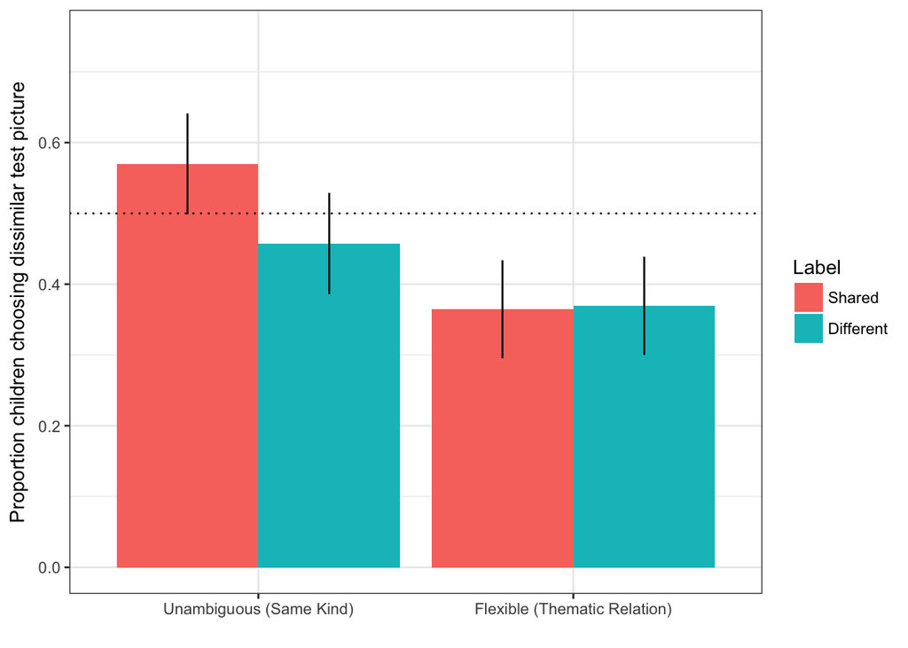

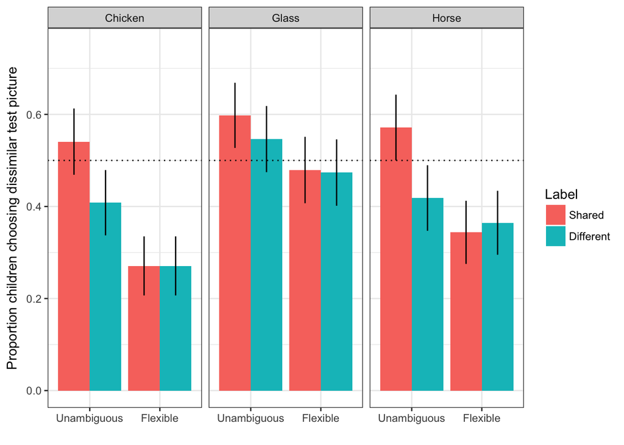

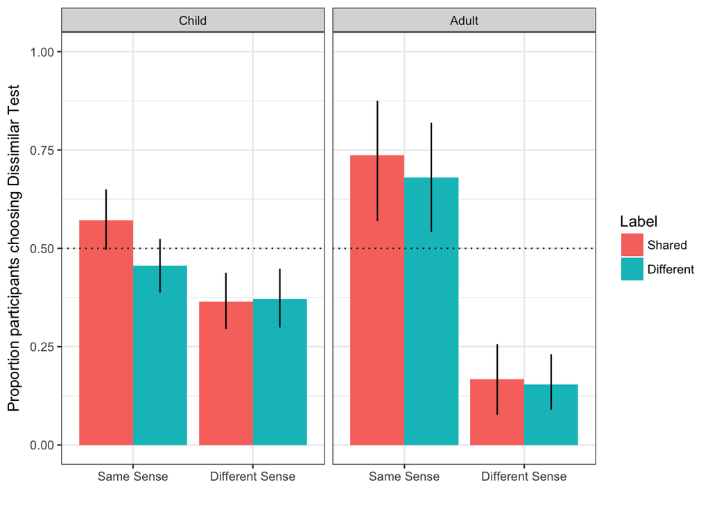

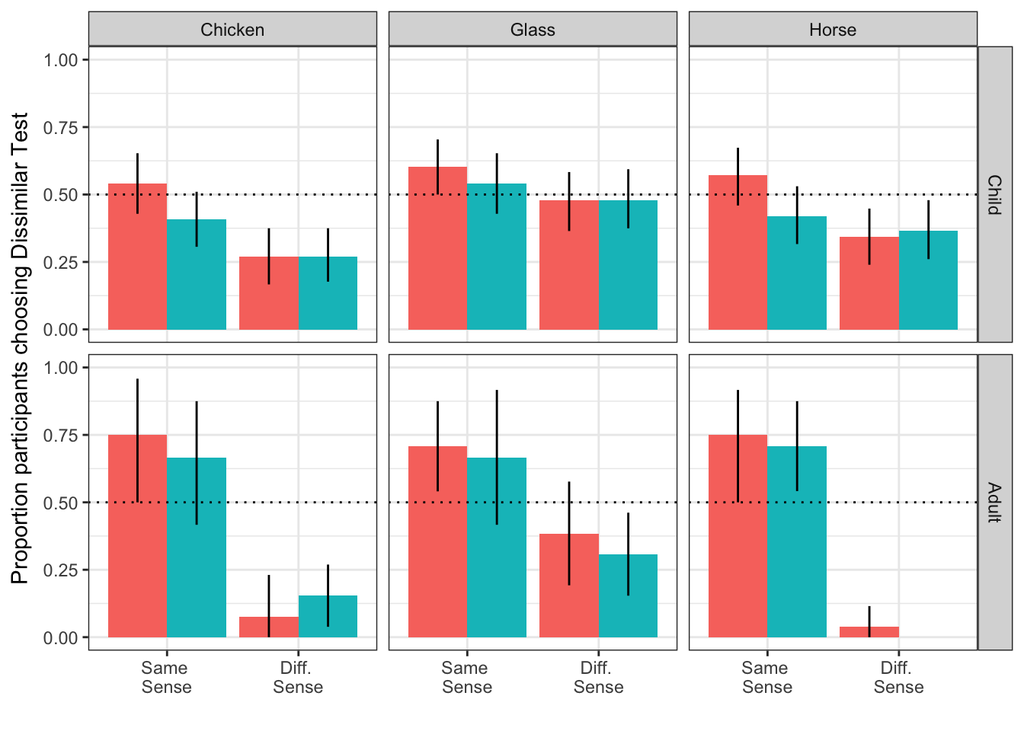

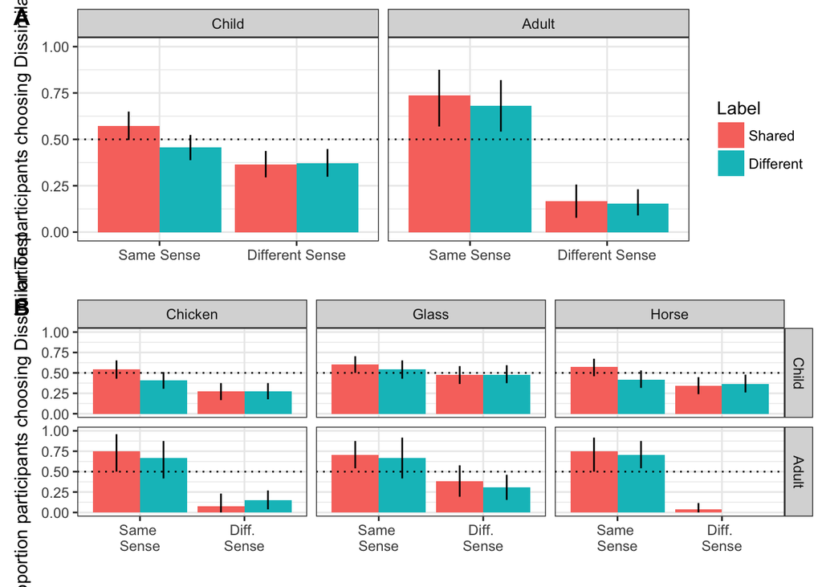

Label * Meaning mixed effects model, followed by t-tests against chance for each condition.

|  | Estimate | Std. Error | z value | Pr(>\|z\|) |
| --- | --- | --- | --- | --- |
| (Intercept) | -0.29 | 0.19 | -1.51 | 0.13 |
| Meaning.L | -0.51 | 0.16 | -3.23 | 0.00 |
| LabelTypeDifferent | -0.13 | 0.09 | -1.43 | 0.15 |
| Meaning.L:LabelTypeDifferent | 0.20 | 0.13 | 1.59 | 0.11 |

|  | Estimate | Std. Error | z value | Pr(>\|z\|) |
| --- | --- | --- | --- | --- |
| (Intercept) | 0.07 | 0.14 | 0.53 | 0.60 |
| LabelTypeDifferent | -0.27 | 0.13 | -2.01 | 0.04 |

|  | Estimate | Std. Error | z value | Pr(>\|z\|) |
| --- | --- | --- | --- | --- |
| (Intercept) | -0.66 | 0.28 | -2.38 | 0.02 |
| LabelTypeDifferent | 0.00 | 0.12 | -0.02 | 0.98 |

| WordType | LabelType | Choice.mean | Choice.sd |
| --- | --- | --- | --- |
| Polysemous | Same | 0.3645833 | 0.2518402 |
| Polysemous | Different | 0.3687500 | 0.2657258 |
| Non-Polysemous | Same | 0.5700680 | 0.2781590 |
| Non-Polysemous | Different | 0.4564626 | 0.2556042 |

```
##
##  One Sample t-test
##
## data:  subset(Child.Sum, WordType == "Non-Polysemous" & LabelType ==     "Same")$Choice
## t = 1.7633, df = 48, p-value = 0.08422
## alternative hypothesis: true mean is not equal to 0.5
## 95 percent confidence interval:
##  0.4901714 0.6499646
## sample estimates:
## mean of x
##  0.570068
```

```
##
##  One Sample t-test
##
## data:  subset(Child.Sum, WordType == "Non-Polysemous" & LabelType ==     "Different")$Choice
## t = -1.1923, df = 48, p-value = 0.239
## alternative hypothesis: true mean is not equal to 0.5
## 95 percent confidence interval:
##  0.3830445 0.5298807
## sample estimates:
## mean of x
## 0.4564626
```

```
##
##  One Sample t-test
##
## data:  subset(Child.Sum, WordType == "Polysemous" & LabelType == "Different")$Choice
## t = -3.422, df = 47, p-value = 0.001297
## alternative hypothesis: true mean is not equal to 0.5
## 95 percent confidence interval:
##  0.2915913 0.4459087
## sample estimates:
## mean of x
##   0.36875
```

```
##
##  One Sample t-test
##
## data:  subset(Child.Sum, WordType == "Polysemous" & LabelType == "Same")$Choice
## t = -3.7254, df = 47, p-value = 0.0005223
## alternative hypothesis: true mean is not equal to 0.5
## 95 percent confidence interval:
##  0.2914566 0.4377101
## sample estimates:
## mean of x
## 0.3645833
```

[output not shown]

```
## Bayes factor analysis
## --------------
## [1] Alt., r=0.707 : 0.1573786 ±0%
##
## Against denominator:
##   Null, mu = 0
## ---
## Bayes factor type: BFoneSample, JZS
```

## Comparison of Experiments 1 and 2

### Adults

[figure not shown]

And data analysis

```
## [1] 49
```

|  | Estimate | Std. Error | z value | Pr(>\|z\|) |
| --- | --- | --- | --- | --- |
| (Intercept) | -0.81 | 0.16 | -5.06 | 0.00 |
| MeaningFlexible (Thematic Relation) | -1.13 | 0.16 | -6.99 | 0.00 |
| Label_cOther | -0.60 | 0.12 | -5.10 | 0.00 |
| ExptExpt2 | -0.42 | 0.16 | -2.65 | 0.01 |
| MeaningFlexible (Thematic Relation):Label_cOther | 0.07 | 0.12 | 0.58 | 0.56 |
| MeaningFlexible (Thematic Relation):ExptExpt2 | 0.28 | 0.16 | 1.75 | 0.08 |
| Label_cOther:ExptExpt2 | -0.50 | 0.12 | -4.24 | 0.00 |
| MeaningFlexible (Thematic Relation):Label_cOther:ExptExpt2 | 0.02 | 0.12 | 0.13 | 0.90 |

### Children

[figure not shown]

And data analysis

|  | Estimate | Std. Error | z value | Pr(>\|z\|) |
| --- | --- | --- | --- | --- |
| (Intercept) | -0.37 | 0.20 | -1.82 | 0.07 |
| MeaningFlexible (Thematic Relation) | -0.33 | 0.09 | -3.74 | 0.00 |
| Label_cOther | -0.30 | 0.07 | -4.61 | 0.00 |
| ExptExpt2 | -0.07 | 0.06 | -1.13 | 0.26 |
| MeaningFlexible (Thematic Relation):Label_cOther | 0.08 | 0.07 | 1.20 | 0.23 |
| MeaningFlexible (Thematic Relation):ExptExpt2 | 0.03 | 0.06 | 0.55 | 0.58 |
| Label_cOther:ExptExpt2 | -0.18 | 0.07 | -2.77 | 0.01 |
| MeaningFlexible (Thematic Relation):Label_cOther:ExptExpt2 | -0.06 | 0.07 | -0.90 | 0.37 |

We can also look at how this varies by age

[figure not shown]

And analysis (note that model doesn’t converge with random intercepts for subjects, just items).

|  | Estimate | Std. Error | z value | Pr(>\|z\|) |
| --- | --- | --- | --- | --- |
| (Intercept) | -0.33 | 0.18 | -1.81 | 0.07 |
| MeaningFlexible (Thematic Relation) | -0.30 | 0.06 | -5.21 | 0.00 |
| Label_cOther | -0.28 | 0.04 | -6.25 | 0.00 |
| Age4 | 0.01 | 0.06 | 0.13 | 0.89 |
| ExptExpt2 | -0.07 | 0.06 | -1.17 | 0.24 |
| MeaningFlexible (Thematic Relation):Label_cOther | 0.07 | 0.04 | 1.64 | 0.10 |
| MeaningFlexible (Thematic Relation):Age4 | -0.09 | 0.06 | -1.65 | 0.10 |
| Label_cOther:Age4 | 0.00 | 0.04 | 0.07 | 0.94 |
| MeaningFlexible (Thematic Relation):ExptExpt2 | 0.03 | 0.06 | 0.55 | 0.58 |
| Label_cOther:ExptExpt2 | -0.16 | 0.04 | -3.66 | 0.00 |
| Age4:ExptExpt2 | -0.08 | 0.06 | -1.48 | 0.14 |
| MeaningFlexible (Thematic Relation):Label_cOther:Age4 | 0.00 | 0.04 | -0.06 | 0.95 |
| MeaningFlexible (Thematic Relation):Label_cOther:ExptExpt2 | -0.05 | 0.04 | -1.22 | 0.22 |
| MeaningFlexible (Thematic Relation):Age4:ExptExpt2 | 0.01 | 0.06 | 0.16 | 0.88 |
| Label_cOther:Age4:ExptExpt2 | -0.02 | 0.04 | -0.48 | 0.63 |
| MeaningFlexible (Thematic Relation):Label_cOther:Age4:ExptExpt2 | 0.05 | 0.04 | 1.10 | 0.27 |

## Analysis of vocab survey

Proportion of labels and synonyms that parents rate that their child knows, or rate that they are unsures if the child knows.

```r
library(tidyr)
library(dplyr)
vocab.w <-read.csv("./Data/VocabSurvey/Vocab_Full.csv", header = T)
vocab <- gather(vocab.w, word, response,rocker:glass.windowpane,factor_key = TRUE)
vocab <- subset(vocab, word %in% c("rocker","chicken.drumstick","chicken.hen","zebra","horse.foal","plastic","glass.cup","windowpane","cup","duck","horse.rocker","foal","drumsticks","hen","glass.windowpane"))
vocab$word <- ordered(vocab$word, levels = c("chicken.hen","hen","chicken.drumstick","drumsticks","duck",
                                             "glass.windowpane","windowpane","glass.cup","cup","plastic",
                                             "horse.foal","foal","horse.rocker","rocker","zebra"))
vocab$known <- ifelse(vocab$response %in% c("yes","notsure"),1,0)
summaryBy(known ~ word, data = vocab)
```

```
##                 word known.mean
## 1        chicken.hen  1.0000000
## 2                hen  0.8493151
## 3  chicken.drumstick  0.8630137
## 4         drumsticks  0.4109589
## 5               duck  0.9315068
## 6   glass.windowpane  0.8630137
## 7         windowpane  0.5890411
## 8          glass.cup  0.9863014
## 9                cup  0.8356164
## 10           plastic  0.8082192
## 11        horse.foal  0.9863014
## 12              foal  0.5068493
## 13      horse.rocker  0.9315068
## 14            rocker  0.8356164
## 15             zebra  0.9863014
```

#### Discussion

No robust effect of synonyms, and effect was signif different between two experiments.

### Gen discussion

What can lex flex tell us about role of labels in induction?

What can induction tell us about children’s early word meanings?